# PR-AUC + SMOTE + Explainable AI

Biostatistics 735 — Machine Learning in Public Health

Author

Alexander McLain

Published

October 29, 2026

# 1 Overview

This notebook demonstrates **explainable AI** methods on a classic public-health dataset: **Pima Indians Diabetes**. We will:

- Prepare data (imputation, scaling)
- Fit a **Random Forest** classifier (primary model) and a **Logistic Regression** baseline
- Evaluate discrimination and calibration, including **precision–recall (PR) curves and PR-AUC**
- Handle class imbalance with **SMOTE**, and compare it to weighting the loss function and moving the classification threshold
- Explain the model with:
  - **Variable Importance (permutation)**
  - **Partial Dependence Plots (PDPs)**
  - **Accumulated Local Effects (ALE)**
  - **SHAP values** (local + global summaries)
  - **LIME** (local surrogate explanations)

We use `tidymodels` for modeling, `themis` for SMOTE, and `vip`, `pdp`, `iml`/`fastshap`, and `lime` for interpretability.

# 2 Packages

```r
# Core modeling
library(tidymodels)     # rsample, recipes, parsnip, workflows, tune, yardstick
library(tidyverse)
library(pROC)
# Class imbalance
library(themis)         # step_smote() and other sampling steps for recipes
# Interpretability
library(vip)            # variable importance + handy plots
library(pdp)            # partial dependence
library(ALEPlot)        # ALE for classical interface
library(iml)            # model-agnostic interface (PDP/ALE/SHAP)
library(fastshap)       # fast SHAP approximations
library(lime)           # LIME local explanations
# Misc
library(ranger)         # Fast implementation of random forests
library(kableExtra)
kbl2 <- function(x, ...) kable(x, align = "lrrrrrr", ...) %>% kable_styling(full_width = FALSE)
```

# 3 Data: Pima Indians Diabetes

```r
data(pima, package = "pdp")   # Pima Indians Diabetes data (with NAs), from the pdp package
df <- pima %>%
  as_tibble()

glimpse(df)
```

```
Rows: 768
Columns: 9
$ pregnant <dbl> 6, 1, 8, 1, 0, 5, 3, 10, 2, 8, 4, 10, 10, 1, 5, 7, 0, 7, 1, 1…
$ glucose  <dbl> 148, 85, 183, 89, 137, 116, 78, 115, 197, 125, 110, 168, 139,…
$ pressure <dbl> 72, 66, 64, 66, 40, 74, 50, NA, 70, 96, 92, 74, 80, 60, 72, N…
$ triceps  <dbl> 35, 29, NA, 23, 35, NA, 32, NA, 45, NA, NA, NA, NA, 23, 19, N…
$ insulin  <dbl> NA, NA, NA, 94, 168, NA, 88, NA, 543, NA, NA, NA, NA, 846, 17…
$ mass     <dbl> 33.6, 26.6, 23.3, 28.1, 43.1, 25.6, 31.0, 35.3, 30.5, NA, 37.…
$ pedigree <dbl> 0.627, 0.351, 0.672, 0.167, 2.288, 0.201, 0.248, 0.134, 0.158…
$ age      <dbl> 50, 31, 32, 21, 33, 30, 26, 29, 53, 54, 30, 34, 57, 59, 51, 3…
$ diabetes <fct> pos, neg, pos, neg, pos, neg, pos, neg, pos, pos, neg, pos, n…
```

```r
summary(df$diabetes)
```

```
neg pos
500 268
```

**Outcome:** `diabetes` (factor: `"pos"` vs `"neg"`).  
**Predictors:**

- **pregnant**: Number of times pregnant
- **glucose**: Plasma glucose concentration (glucose tolerance test)
- **pressure**: Diastolic blood pressure (mm Hg)
- **triceps**: Triceps skin fold thickness (mm)
- **insulin**: 2-Hour serum insulin (mu U/ml)
- **mass**: Body mass index
- **pedigree**: Diabetes pedigree function
- **age**: Age (years)
- **diabetes**: Class variable (test for diabetes)

# 4 Train/Test Split and Preprocessing

```r
set.seed(735)
split <- initial_split(df, prop = 0.75, strata = diabetes)
train <- training(split)
test  <- testing(split)

# Recipe: median imputation for numeric; mode for nominal; standardization
rec <- recipe(diabetes ~ ., data = train) %>%
  step_impute_median(all_numeric_predictors()) %>%
  step_impute_mode(all_nominal_predictors()) %>%
  step_normalize(all_numeric_predictors())

prep_rec <- prep(rec)
train_baked <- bake(prep_rec, new_data = train)
test_baked  <- bake(prep_rec, new_data = test)
```

# 5 Models

We fit a **Random Forest** (primary ML model) with basic tuning and a **Logistic Regression** baseline.

```r
set.seed(735)

# Random Forest (tuned mtry, trees fixed moderate)
rf_spec <- rand_forest(mtry = tune(), trees = 1000, min_n = 5) %>%
  set_engine("ranger", importance = "permutation", probability = TRUE) %>%
  set_mode("classification")

log_spec <- logistic_reg(penalty = 0, mixture = 1) %>%
  set_engine("glm")

wf_rf  <- workflow() %>% add_model(rf_spec)  %>% add_recipe(rec)
wf_log <- workflow() %>% add_model(log_spec) %>% add_recipe(rec)

# 5-fold CV
set.seed(735)
folds <- vfold_cv(train, v = 5, strata = diabetes)

grid <- grid_regular(mtry(range = c(2L, ncol(train) - 1L)), levels = 5)

rf_tuned <- tune_grid(
  wf_rf,
  resamples = folds,
  grid = grid,
  metrics = metric_set(roc_auc, pr_auc, accuracy, kap),
  # "pos" is the second level of diabetes; this makes pr_auc about the pos class
  control = control_grid(event_level = "second")
)

show_best(rf_tuned, metric = "roc_auc", n = 3)
```

```
# A tibble: 3 × 7
   mtry .metric .estimator  mean     n std_err .config
  <int> <chr>   <chr>      <dbl> <int>   <dbl> <chr>
1     2 roc_auc binary     0.820     5 0.00519 pre0_mod1_post0
2     3 roc_auc binary     0.816     5 0.00369 pre0_mod2_post0
3     6 roc_auc binary     0.814     5 0.00635 pre0_mod4_post0
```

```r
best_params <- select_best(rf_tuned, metric = "roc_auc")
rf_final <- finalize_workflow(wf_rf, best_params)

# Fit final models on training data
fit_rf  <- fit(rf_final, data = train)
fit_log <- fit(wf_log,  data = train)
```

# 6 Performance on Test Set

```r
pred_rf  <- predict(fit_rf,  test, type = "prob") %>% bind_cols(predict(fit_rf,  test)) %>% bind_cols(test %>% select(diabetes))
pred_log <- predict(fit_log, test, type = "prob") %>% bind_cols(predict(fit_log, test)) %>% bind_cols(test %>% select(diabetes))

# ROC AUC / PR AUC / Accuracy
# event_level = "second" means the event of interest is "pos" (the second level)
roc_rf <- pred_rf  %>% roc_auc(truth = diabetes, .pred_pos, event_level = "second")
metrics_rf  <-  roc_rf %>%
  bind_rows(pr_auc(pred_rf, truth = diabetes, .pred_pos, event_level = "second")) %>%
  bind_rows(accuracy(pred_rf, truth = diabetes, .pred_class)) %>%
  rename(RF_estimate = .estimate)
roc_log <- pred_log %>% roc_auc(truth = diabetes, .pred_pos, event_level = "second")
metrics_log <- roc_log %>%
  bind_rows(pr_auc(pred_log, truth = diabetes, .pred_pos, event_level = "second")) %>%
  bind_rows(accuracy(pred_log, truth = diabetes, .pred_class)) %>%
  rename(Logit_estimate = .estimate)

metrics_rf %>% left_join(metrics_log) %>% kbl2(digits = 3)
```

| .metric | .estimator | RF_estimate | Logit_estimate |
| --- | --- | --- | --- |
| roc_auc | binary | 0.865 | 0.858 |
| pr_auc | binary | 0.775 | 0.748 |
| accuracy | binary | 0.792 | 0.776 |

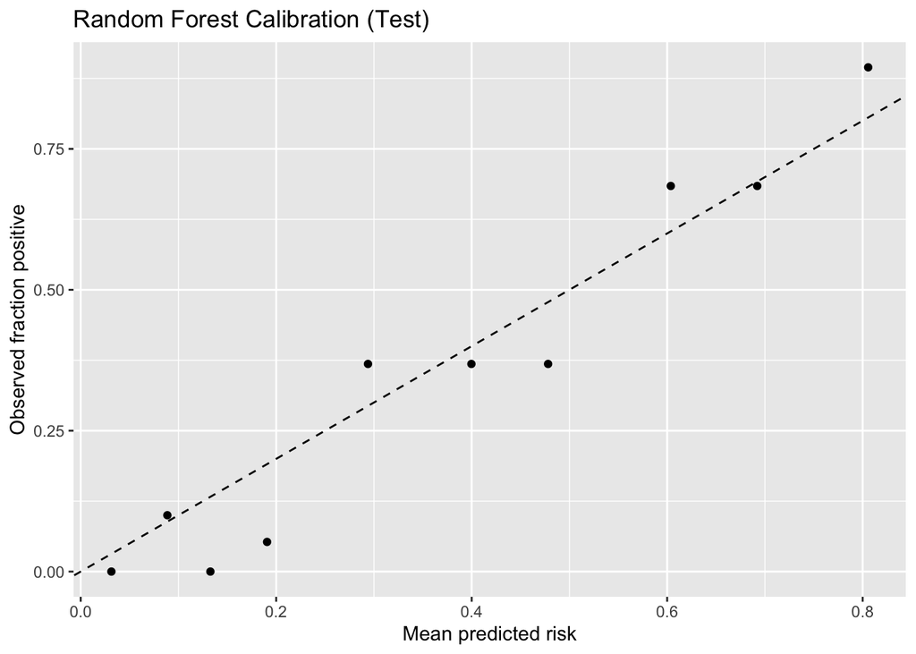

```r
# Calibration
pred_rf_cal <- pred_rf %>% mutate(bin = ntile(.pred_pos, 10)) %>% group_by(bin) %>%
  summarise(mean_pred = mean(.pred_pos), obs = mean(diabetes == "pos"), n = n())

ggplot(pred_rf_cal, aes(x = mean_pred, y = obs)) +
  geom_point() + geom_abline(slope = 1, intercept = 0, linetype = 2) +
  labs(title = "Random Forest Calibration (Test)", x = "Mean predicted risk", y = "Observed fraction positive")
```

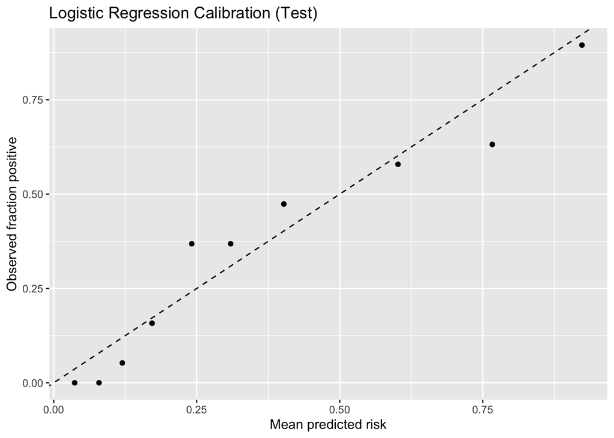

```r
# Calibration (optional, simple reliability plot)
pred_log_cal <- pred_log %>% mutate(bin = ntile(.pred_pos, 10)) %>% group_by(bin) %>%
  summarise(mean_pred = mean(.pred_pos), obs = mean(diabetes == "pos"), n = n())

ggplot(pred_log_cal, aes(x = mean_pred, y = obs)) +
  geom_point() + geom_abline(slope = 1, intercept = 0, linetype = 2) +
  labs(title = "Logistic Regression Calibration (Test)", x = "Mean predicted risk", y = "Observed fraction positive")
```

## 6.1 Precision–Recall Curves and PR-AUC

The ROC curve plots sensitivity against 1 − specificity. Specificity is computed from the **negatives**, so when most people are negative, a model can make a lot of false positives and still have a small false positive rate. A precision–recall (PR) curve focuses on the **positive** class instead.

Using the confusion matrix at a given threshold:

- **Recall** $= \frac{TP}{TP + FN}$, which is the sensitivity: of the people with diabetes, what fraction did we flag?
- **Precision** $= \frac{TP}{TP + FP}$, which is the positive predictive value (PPV): of the people we flagged, what fraction actually have diabetes?

The PR curve plots precision against recall as the threshold moves from 1 down to 0, and **PR-AUC** is the area under it (also called *average precision*). Precision is often the number a public health program cares about: if we send everyone above the threshold to follow-up testing, precision is the share of those visits that find a case.

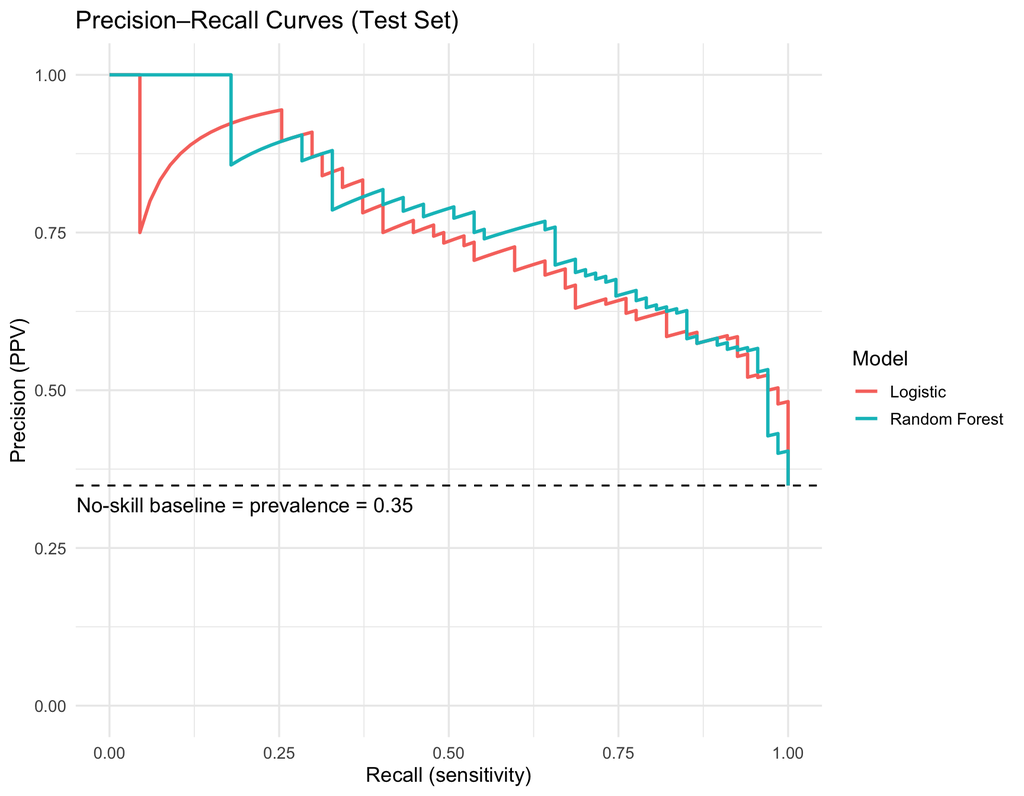

```r
pr_both <- bind_rows(
  pr_curve(pred_rf,  truth = diabetes, .pred_pos, event_level = "second") %>% mutate(Model = "Random Forest"),
  pr_curve(pred_log, truth = diabetes, .pred_pos, event_level = "second") %>% mutate(Model = "Logistic")
)

prevalence <- mean(test$diabetes == "pos")

ggplot(pr_both, aes(x = recall, y = precision, color = Model)) +
  geom_path(linewidth = 1) +
  geom_hline(yintercept = prevalence, linetype = 2) +
  annotate("text", x = 0.2, y = prevalence - 0.03,
           label = paste0("No-skill baseline = prevalence = ", round(prevalence, 2))) +
  coord_cartesian(ylim = c(0, 1)) +
  labs(title = "Precision–Recall Curves (Test Set)", x = "Recall (sensitivity)", y = "Precision (PPV)") +
  theme_minimal(base_size = 13)
```

**Reading the plot.** On the left (high threshold) we only flag the highest-risk people, so precision is high but recall is low. Moving right, we flag more people, catch more cases, and precision falls.

**The baseline is different from ROC.** For ROC-AUC, a useless model scores 0.5. For PR-AUC, a useless model (random guessing) has precision equal to the **prevalence** at every recall, so its PR-AUC is about the prevalence (0.35 here). Always report PR-AUC next to the prevalence.

```r
pr_tab <- tibble(
  Model  = c("Random Forest", "Logistic", "No-skill baseline"),
  PR_AUC = c(pr_auc_vec(pred_rf$diabetes,  pred_rf$.pred_pos,  event_level = "second"),
             pr_auc_vec(pred_log$diabetes, pred_log$.pred_pos, event_level = "second"),
             prevalence)
) %>%
  mutate(Times_baseline = PR_AUC / prevalence)

pr_tab %>% kbl2(digits = 3, caption = "PR-AUC on the test set")
```

PR-AUC on the test set

| Model | PR_AUC | Times_baseline |
| --- | --- | --- |
| Random Forest | 0.775 | 2.220 |
| Logistic | 0.748 | 2.142 |
| No-skill baseline | 0.349 | 1.000 |

**What the PR-AUC is.** PR-AUC is the area under the PR curve. Since precision is on the y-axis and recall runs from 0 to 1 on the x-axis, the area is the **average precision over all levels of recall**. It summarizes the whole curve in one number, without picking a threshold.

**Interpretation.** The random forest has PR-AUC = 0.77. Averaged over all levels of recall, from a strict threshold that catches only a few of the cases to a loose one that catches nearly all of them, about 77% of the women the model flags actually have diabetes. If we flagged women at random, only 35% would (the prevalence). So the model’s flags are about 2.2 times as precise as random flagging. Logistic regression is a little lower (0.75). That gap is small compared with the bootstrap standard errors below, so the two models are roughly equally good at finding cases.

**Important**

**Tell yardstick which class is the event.** `diabetes` has levels `neg`, `pos`, and yardstick treats the *first* level as the event by default. ROC-AUC is the same either way, but PR-AUC is not:

```r
c(pos_is_event = pr_auc_vec(pred_rf$diabetes, pred_rf$.pred_pos, event_level = "second"),
  neg_is_event = pr_auc_vec(pred_rf$diabetes, pred_rf$.pred_neg))
```

```
pos_is_event neg_is_event
   0.7747382    0.9232182
```

The second number answers “how well do we find people **without** diabetes?”, which is not what we want, and it looks better because negatives are the majority. That’s why we used `event_level = "second"` above (and `control_grid(event_level = "second")` in `tune_grid()`).

### 6.1.1 PR-AUC depends on prevalence

To see why the baseline matters, keep the **same fitted random forest** and the same test-set predictions, but randomly drop positive cases so that the prevalence in the test set is 35%, 20%, 10%, or 5%. Repeat 200 times at each prevalence.

```r
set.seed(735)
pos_idx <- which(pred_rf$diabetes == "pos")
neg_idx <- which(pred_rf$diabetes == "neg")

prev_demo <- map_dfr(c(0.35, 0.20, 0.10, 0.05), function(prev) {
  n_pos <- round(prev / (1 - prev) * length(neg_idx))
  map_dfr(1:200, function(r) {
    d <- pred_rf[c(neg_idx, sample(pos_idx, n_pos)), ]
    tibble(
      Prevalence = prev,
      ROC_AUC = roc_auc_vec(d$diabetes, d$.pred_pos, event_level = "second"),
      PR_AUC  = pr_auc_vec(d$diabetes, d$.pred_pos, event_level = "second")
    )
  })
}) %>%
  group_by(Prevalence) %>%
  summarise(ROC_AUC = mean(ROC_AUC), PR_AUC = mean(PR_AUC), .groups = "drop") %>%
  arrange(desc(Prevalence))

prev_demo %>% kbl2(digits = 3, caption = "Same model, different prevalence")
```

Same model, different prevalence

| Prevalence | ROC_AUC | PR_AUC |
| --- | --- | --- |
| 0.35 | 0.865 | 0.775 |
| 0.20 | 0.863 | 0.636 |
| 0.10 | 0.865 | 0.497 |
| 0.05 | 0.868 | 0.381 |

ROC-AUC barely changes because it only depends on how positives are ranked relative to negatives. PR-AUC drops a lot, because with fewer cases a larger share of the people we flag are false positives. Two consequences:

- For a **rare outcome**, PR-AUC shows how hard the problem really is; a ROC-AUC of 0.87 can look reassuring even when most flagged people are false positives.
- **Don’t compare PR-AUC across data sets (or subgroups) with different prevalence** without also reporting the prevalence of each.

## 6.2 Estimating predictive SE using boostrapping

```r
set.seed(123)   # for reproducibility
nboot <- 1000   # number of bootstrap replicates
n <- nrow(test)

# Storage for results
auc_log <- acc_log <- prauc_log <- numeric(nboot)
auc_rf  <- acc_rf  <- prauc_rf  <- numeric(nboot)

# Begin bootstrap
for (b in 1:nboot) {
  # Get boostrap sample
  idx <- sample(1:n, size = n, replace = TRUE)
  test_b <- test[idx, ]

  # Logistic model predictions
  prob_log <- predict(fit_log, test_b, type = "prob")$.pred_pos
  pred_log <- factor(ifelse(prob_log > 0.5, "pos", "neg"),
                     levels = c("neg", "pos"))

  # Random Forest predictions
  prob_rf <- predict(fit_rf, test_b, type = "prob")$.pred_pos
  pred_rf <- factor(ifelse(prob_rf > 0.5, "pos", "neg"),
                     levels = c("neg", "pos"))

  # --- Logistic model metrics ---
  auc_log[b] <- as.numeric(roc(test_b$diabetes, prob_log, quiet = TRUE)$auc)
  acc_log[b] <- mean(pred_log == test_b$diabetes)
  prauc_log[b] <- pr_auc_vec(test_b$diabetes, prob_log, event_level = "second")

  # --- Random forest metrics ---
  auc_rf[b]  <- as.numeric(roc(test_b$diabetes, prob_rf, quiet = TRUE)$auc)
  acc_rf[b]  <- mean(pred_rf == test_b$diabetes)
  prauc_rf[b]  <- pr_auc_vec(test_b$diabetes, prob_rf, event_level = "second")
}

# Summarize results
summary_stats <- tibble(
  Model = c("Logistic", "Random Forest"),
  AUC_mean = c(mean(auc_log), mean(auc_rf)),
  AUC_se   = c(sd(auc_log), sd(auc_rf)),
  AUC_95CI_lower = c(quantile(auc_log, 0.025), quantile(auc_rf, 0.025)),
  AUC_95CI_upper = c(quantile(auc_log, 0.975), quantile(auc_rf, 0.975)),
  PRAUC_mean = c(mean(prauc_log), mean(prauc_rf)),
  PRAUC_se   = c(sd(prauc_log), sd(prauc_rf)),
  PRAUC_95CI_lower = c(quantile(prauc_log, 0.025), quantile(prauc_rf, 0.025)),
  PRAUC_95CI_upper = c(quantile(prauc_log, 0.975), quantile(prauc_rf, 0.975)),
  Acc_mean = c(mean(acc_log), mean(acc_rf)),
  Acc_se   = c(sd(acc_log), sd(acc_rf)),
  Acc_95CI_lower = c(quantile(acc_log, 0.025), quantile(acc_rf, 0.025)),
  Acc_95CI_upper = c(quantile(acc_log, 0.975), quantile(acc_rf, 0.975))
)

summary_stats %>% kbl2(digits = 3)
```

| Model | AUC_mean | AUC_se | AUC_95CI_lower | AUC_95CI_upper | PRAUC_mean | PRAUC_se | PRAUC_95CI_lower | PRAUC_95CI_upper | Acc_mean | Acc_se | Acc_95CI_lower | Acc_95CI_upper |
| --- | --- | --- | --- | --- | --- | --- | --- | --- | --- | --- | --- | --- |
| Logistic | 0.858 | 0.026 | 0.802 | 0.906 | 0.747 | 0.056 | 0.627 | 0.840 | 0.778 | 0.029 | 0.719 | 0.833 |
| Random Forest | 0.866 | 0.027 | 0.808 | 0.914 | 0.776 | 0.048 | 0.675 | 0.856 | 0.793 | 0.029 | 0.734 | 0.854 |

# 7 Class Imbalance and SMOTE

About 35% of the Pima women have diabetes, so the outcome is moderately imbalanced. At the default 0.5 threshold, both models miss a lot of cases (look at the sensitivity below). We have already seen some ways to deal with this:

- **Downsampling** the majority class or **upsampling** the minority class by copying rows (Data Preprocessing notes).
- **Weighting the loss function** so that a missed case costs more than a missed non-case (Neural Networks II).
- **Moving the threshold** away from 0.5 (Neural Networks II).

**SMOTE** (*Synthetic Minority Over-sampling TEchnique*) is a more refined version of upsampling. Copying rows means a random forest sees the *exact same* person many times, which encourages it to memorize those people. SMOTE instead creates new, *synthetic* minority-class observations that are similar to, but not copies of, the real ones.

## 7.1 How SMOTE works

For each new synthetic observation:

1. Pick a minority-class observation $x_i$ (here, a woman with diabetes).
2. Find its $k$ nearest neighbors **among the minority class** (default $k = 5$).
3. Pick one of those neighbors, $x_{nn}$, at random.
4. Create a new point on the line segment between them:
   $$x_{new} = x_i + u\,(x_{nn} - x_i), \qquad u \sim \text{Uniform}(0, 1).$$

Repeat until the classes are the desired size (by default, equal). Because SMOTE uses nearest neighbors, it needs **numeric, standardized predictors with no missing values**, so it goes *after* imputation and normalization.

Here is SMOTE on a small sample, using only two predictors so we can see it:

```r
set.seed(735)
toy <- train_baked %>%
  select(glucose, mass, diabetes) %>%
  slice_sample(n = 150)

toy_smote <- themis::smote(toy, var = "diabetes", k = 5, over_ratio = 1)

count(toy, diabetes)
```

```
# A tibble: 2 × 2
  diabetes     n
  <fct>    <int>
1 neg         98
2 pos         52
```

```r
count(toy_smote, diabetes)
```

```
# A tibble: 2 × 2
  diabetes     n
  <fct>    <int>
1 neg         98
2 pos         98
```

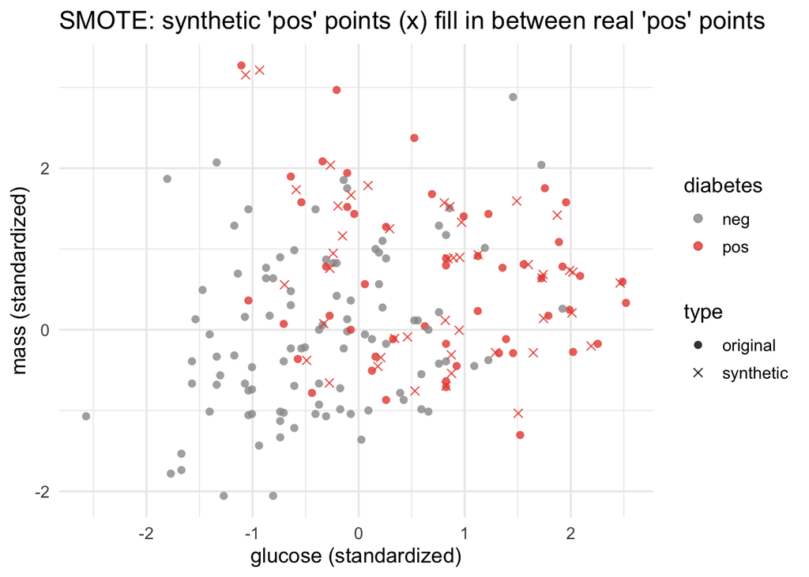

```r
# Synthetic rows are the ones that aren't in the original data
toy_plot <- bind_rows(
  toy %>% mutate(type = "original"),
  anti_join(toy_smote, toy, by = c("glucose", "mass", "diabetes")) %>% mutate(type = "synthetic")
)

ggplot(toy_plot, aes(glucose, mass, color = diabetes, shape = type)) +
  geom_point(size = 2, alpha = 0.8) +
  scale_shape_manual(values = c(original = 16, synthetic = 4)) +
  scale_color_manual(values = c(neg = "grey60", pos = "#E74C3C")) +
  labs(title = "SMOTE: synthetic 'pos' points (x) fill in between real 'pos' points",
       x = "glucose (standardized)", y = "mass (standardized)") +
  theme_minimal(base_size = 13)
```

The synthetic points (×) all fall between real diabetic women, so SMOTE fills in the region where the minority class already lives. It doesn’t create cases in new places.

## 7.2 SMOTE goes in the recipe (training data only)

The most important rule: **only apply SMOTE to the training data.** The test set (and each CV assessment fold) must keep the real prevalence, or our performance estimates describe a population that doesn’t exist. Putting `step_smote()` in the recipe takes care of this:

- Inside `fit_resamples()` / `tune_grid()`, the recipe is re-prepped within each fold, so SMOTE only uses that fold’s analysis data.
- `step_smote()` has `skip = TRUE`, so it is **not** applied when we `bake()` or `predict()` on new data.

```r
rec_smote <- rec %>%
  step_smote(diabetes, over_ratio = 1, neighbors = 5)   # make pos as common as neg

# Training data after the recipe: balanced
prep(rec_smote) %>% bake(new_data = NULL) %>% count(diabetes)
```

```
# A tibble: 2 × 2
  diabetes     n
  <fct>    <int>
1 neg        375
2 pos        375
```

```r
# Test data after the recipe: unchanged
prep(rec_smote) %>% bake(new_data = test) %>% count(diabetes)
```

```
# A tibble: 2 × 2
  diabetes     n
  <fct>    <int>
1 neg        125
2 pos         67
```

**Warning**

Running SMOTE on the full data *before* splitting is a form of leakage: synthetic training points are built from people who end up in the test set, and the test set itself becomes 50% positive. Both make the results look better than they will be.

## 7.3 Comparing the options

We compare six versions on the test set:

- Logistic regression and random forest, as fit above.
- Each with SMOTE added to the recipe (the random forest keeps the `mtry` chosen above).
- Logistic regression with a **weighted loss**, using the same weights as in Neural Networks II: each class gets weight proportional to $1/n_{class}$, scaled so the weights average to about 1. In tidymodels this is done with *case weights*.

```r
# Weighted loss: same formula as class_weights in Neural Networks II
class_wts <- train %>%
  count(diabetes) %>%
  mutate(wt = (1 / n) / sum(1 / n) * 2)
class_wts
```

```
# A tibble: 2 × 3
  diabetes     n    wt
  <fct>    <int> <dbl>
1 neg        375 0.698
2 pos        201 1.30
```

```r
train_w <- train %>%
  left_join(class_wts %>% select(diabetes, wt), by = "diabetes") %>%
  mutate(wt = importance_weights(wt))

# The recipe has to be built on data that includes the weight column
rec_w <- recipe(diabetes ~ ., data = train_w) %>%
  step_impute_median(all_numeric_predictors()) %>%
  step_impute_mode(all_nominal_predictors()) %>%
  step_normalize(all_numeric_predictors())

set.seed(735)
fit_log_smote <- workflow() %>% add_model(log_spec) %>% add_recipe(rec_smote) %>% fit(data = train)
fit_log_wt    <- workflow() %>% add_model(log_spec) %>% add_recipe(rec_w) %>%
  add_case_weights(wt) %>% fit(data = train_w)
fit_rf_smote  <- rf_final %>% update_recipe(rec_smote) %>% fit(data = train)
```

The last option, from Neural Networks II, is to keep the original (unweighted, no SMOTE) logistic model and **lower the threshold**. The threshold is a tuning parameter, so we choose it using cross-validated predictions on the training data (maximizing Youden’s $J = \text{Sens} + \text{Spec} - 1$), not the test set.

```r
set.seed(735)
cv_log <- fit_resamples(wf_log, resamples = folds,
                        control = control_resamples(save_pred = TRUE, event_level = "second"))

thr_youden <- collect_predictions(cv_log) %>%
  roc_curve(truth = diabetes, .pred_pos, event_level = "second") %>%
  mutate(J = sensitivity + specificity - 1) %>%
  slice_max(J, n = 1, with_ties = FALSE) %>%
  pull(.threshold)
thr_youden
```

```
[1] 0.2680828
```

```r
test_metrics <- function(fit, threshold = 0.5) {
  p <- predict(fit, test, type = "prob")$.pred_pos
  truth <- test$diabetes
  cls <- factor(ifelse(p >= threshold, "pos", "neg"), levels = c("neg", "pos"))
  tibble(
    ROC_AUC   = roc_auc_vec(truth, p, event_level = "second"),
    PR_AUC    = pr_auc_vec(truth, p, event_level = "second"),
    Sens      = sens_vec(truth, cls, event_level = "second"),
    Spec      = spec_vec(truth, cls, event_level = "second"),
    Precision = precision_vec(truth, cls, event_level = "second"),
    Mean_pred_risk = mean(p),
    Obs_prevalence = mean(truth == "pos")
  )
}

imb_results <- bind_rows(
  test_metrics(fit_log)                    %>% mutate(Model = "Logistic", Threshold = "0.5"),
  test_metrics(fit_log_smote)              %>% mutate(Model = "Logistic + SMOTE", Threshold = "0.5"),
  test_metrics(fit_log_wt)                 %>% mutate(Model = "Logistic + weighted loss", Threshold = "0.5"),
  test_metrics(fit_log, thr_youden)        %>% mutate(Model = "Logistic", Threshold = "Youden (CV)"),
  test_metrics(fit_rf)                     %>% mutate(Model = "Random Forest", Threshold = "0.5"),
  test_metrics(fit_rf_smote)               %>% mutate(Model = "Random Forest + SMOTE", Threshold = "0.5")
) %>%
  relocate(Model, Threshold)

imb_results %>% kbl2(digits = 3, caption = "Handling imbalance (test set)")
```

Handling imbalance (test set)

| Model | Threshold | ROC_AUC | PR_AUC | Sens | Spec | Precision | Mean_pred_risk | Obs_prevalence |
| --- | --- | --- | --- | --- | --- | --- | --- | --- |
| Logistic | 0.5 | 0.858 | 0.748 | 0.597 | 0.872 | 0.714 | 0.362 | 0.349 |
| Logistic + SMOTE | 0.5 | 0.856 | 0.754 | 0.687 | 0.800 | 0.648 | 0.457 | 0.349 |
| Logistic + weighted loss | 0.5 | 0.859 | 0.747 | 0.687 | 0.792 | 0.639 | 0.456 | 0.349 |
| Logistic | Youden (CV) | 0.858 | 0.748 | 0.851 | 0.688 | 0.594 | 0.362 | 0.349 |
| Random Forest | 0.5 | 0.865 | 0.775 | 0.657 | 0.864 | 0.721 | 0.368 | 0.349 |
| Random Forest + SMOTE | 0.5 | 0.866 | 0.769 | 0.806 | 0.768 | 0.651 | 0.425 | 0.349 |

**What to notice:**

- **ROC-AUC and PR-AUC hardly change.** SMOTE and weighting don’t make the model better at *ranking* people by risk. They mostly shift the predicted probabilities up.
- **At the 0.5 threshold, sensitivity goes up and specificity and precision go down.** We catch more cases at the cost of more false positives.
- **SMOTE and the weighted loss give nearly the same logistic model.** Both tell the model to act as if cases are as common as non-cases. One does it by adding synthetic rows, the other by up-weighting the real ones.
- **Moving the threshold** on the original model gives the same kind of trade-off without changing the training data at all. Here Youden’s $J$ picked a low threshold (0.27), so it moves further toward sensitivity than SMOTE did. Notice that its `Mean_pred_risk` is unchanged: the predicted risks are still the original model’s.

## 7.4 SMOTE distorts predicted risks

Look at the `Mean_pred_risk` column: after SMOTE or weighting, the average predicted risk is well above the observed prevalence. The model was trained on data where 50% of people have diabetes, so its probabilities describe that population, not ours.

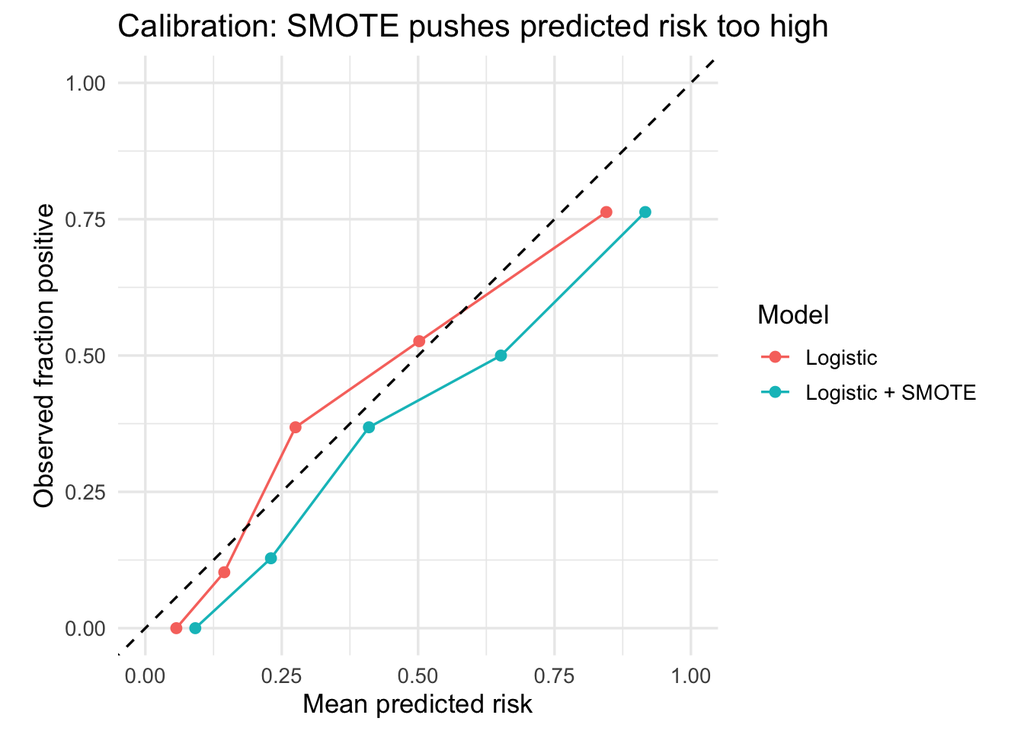

```r
bind_rows(
  predict(fit_log,       test, type = "prob") %>% mutate(Model = "Logistic"),
  predict(fit_log_smote, test, type = "prob") %>% mutate(Model = "Logistic + SMOTE")
) %>%
  mutate(diabetes = rep(test$diabetes, 2)) %>%
  group_by(Model) %>%
  mutate(bin = ntile(.pred_pos, 5)) %>%
  group_by(Model, bin) %>%
  summarise(mean_pred = mean(.pred_pos), obs = mean(diabetes == "pos"), .groups = "drop") %>%
  ggplot(aes(mean_pred, obs, color = Model)) +
  geom_point(size = 2) + geom_line() +
  geom_abline(slope = 1, intercept = 0, linetype = 2) +
  coord_equal(xlim = c(0, 1), ylim = c(0, 1)) +
  labs(title = "Calibration: SMOTE pushes predicted risk too high",
       x = "Mean predicted risk", y = "Observed fraction positive") +
  theme_minimal(base_size = 13)
```

The SMOTE curve sits below the diagonal: people are predicted to be at higher risk than they really are. If predictions will be reported to patients or used to estimate how many cases to expect, this matters. If they’re only used to rank people or to make a yes/no decision at a tuned threshold, it matters less.

**Note**

**When should you use SMOTE?** It is most useful when the outcome is **rare** (say, under 10%) and the model, at the default settings, almost never predicts the minority class. With a moderately imbalanced outcome like this one, the gains are small and moving the threshold does about as well. In any case:

- Apply it to the **training data only** (put it in the recipe).
- Judge it with **ROC-AUC, PR-AUC, and sensitivity/specificity**, not accuracy.
- If you need **calibrated risks**, either skip it or recalibrate the predictions afterwards.

# 8 Explainable AI

## 8.1 Variable Importance (Permutation)

Permutation importance measures the drop in performance when a feature is permuted in the test set.

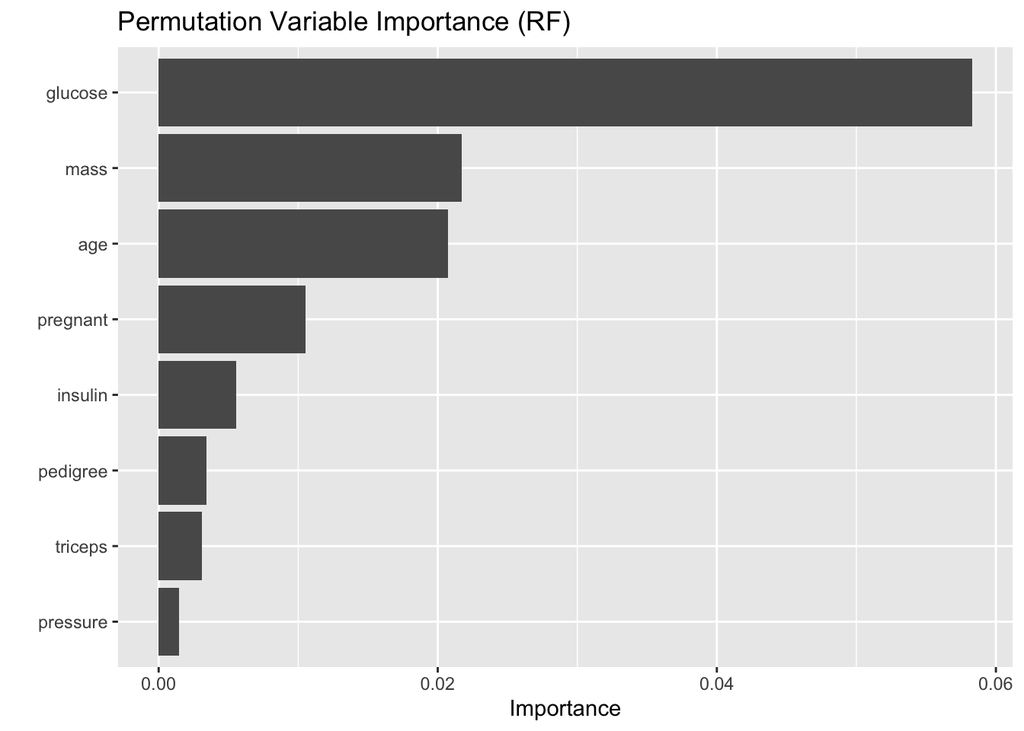

```r
# Extract underlying ranger fit and plot permutation importance
rf_obj <- fit_rf %>% extract_fit_parsnip() %>% pluck("fit")
vip::vip(rf_obj, num_features = 10) +
  labs(title = "Permutation Variable Importance (RF)")
```

## 8.2 Partial Dependence Plots (PDP)

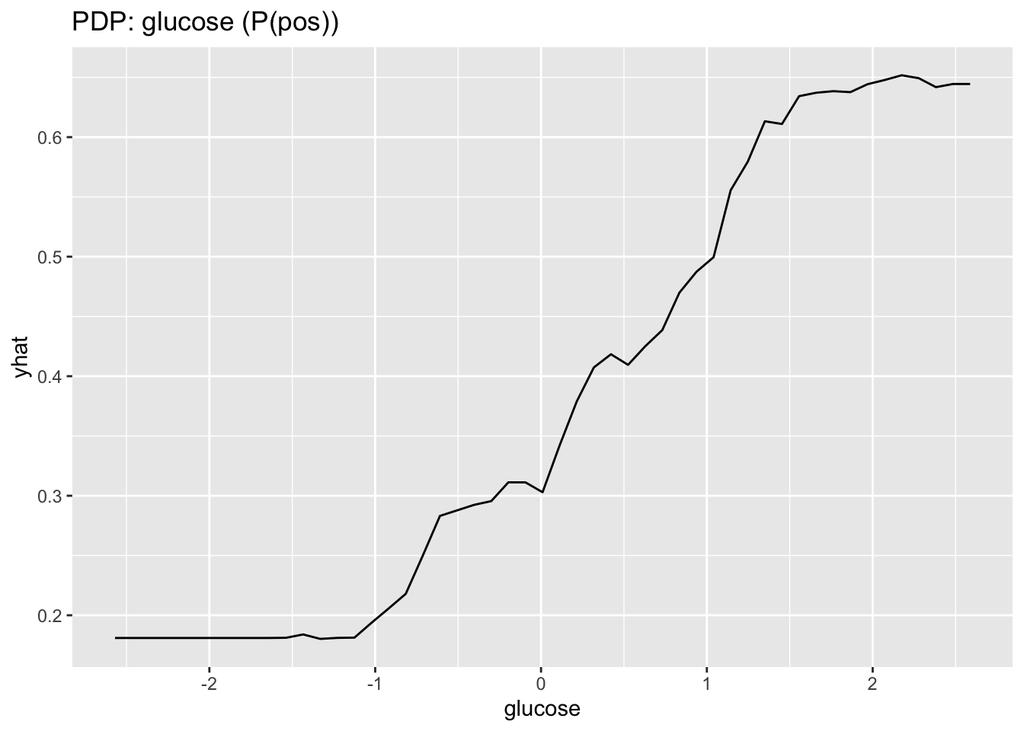

```r
# PDP for key features (example: glucose, mass)
rf_fit <- extract_fit_parsnip(fit_rf)$fit

pdp::partial(
  object      = rf_fit,
  pred.var    = "glucose",
  train       = bake(prep_rec, new_data = train) %>% select(-diabetes),
  prob        = TRUE,
  which.class = 2
) %>% autoplot() + ggtitle("PDP: glucose (P(pos))")
```

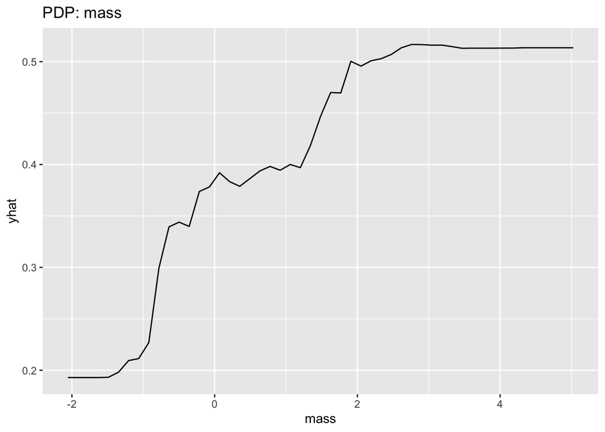

```r
pdp::partial(
  object   = rf_fit,
  pred.var = "mass",
  train    = bake(prep_rec, new_data = train) %>% select(-diabetes),
  prob     = TRUE,
  which.class = 2
) %>% autoplot() + ggtitle("PDP: mass")
```

## 8.3 Accumulated Local Effects (ALE)

ALE is less sensitive than PDP to correlated predictors by aggregating **local** effects.

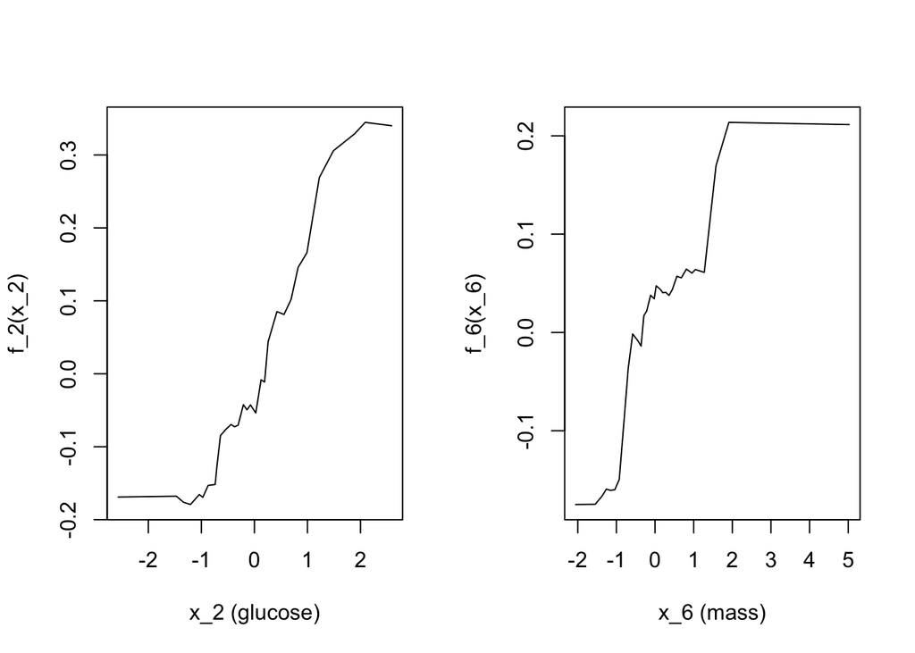

```r
# Extract the underlying ranger model
rf_fit <- extract_fit_parsnip(fit_rf)$fit

# Prepare model matrix and response
train_baked <- bake(prep_rec, new_data = train)
X <- as.data.frame(train_baked %>% select(-diabetes))
y <- train_baked$diabetes

# Define a simple wrapper returning predicted probabilities for the "pos" class
 rf_predict <- function(X.model, newdata) {
   predict(rf_fit, newdata, type = "response")$predictions[, "pos"]
 }

# Compute ALE for glucose
 par(mfrow = c(1,2))
ALE_glu = ALEPlot::ALEPlot(
  X = X,
  X.model = rf_fit,
  pred.fun = rf_predict,
  J = which(names(X) == "glucose"),
  K = 30
  )
ALE_mass = ALEPlot::ALEPlot(
  X = X,
  X.model = rf_fit,
  pred.fun = rf_predict,
  J = which(names(X) == "mass"),
  K = 30
  )
```

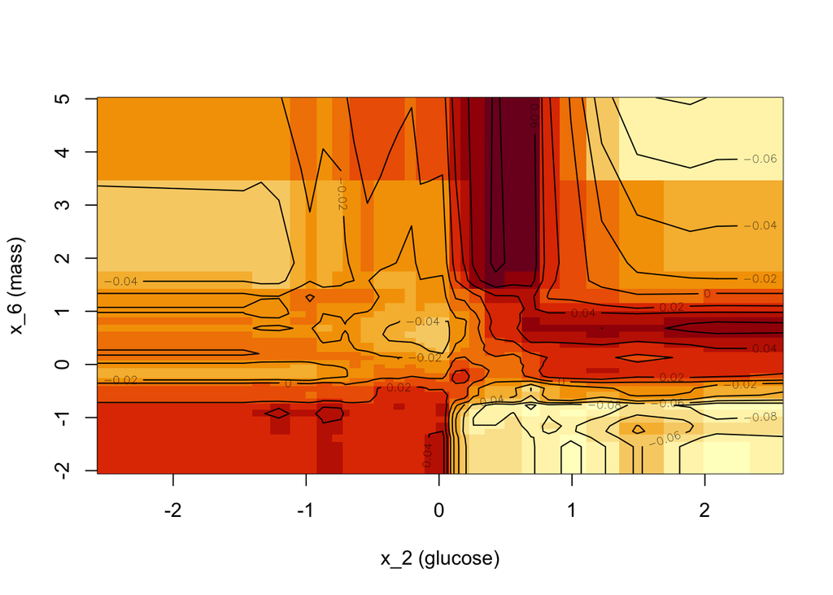

```r
 par(mfrow = c(1,1))
ALE_glumass = ALEPlot::ALEPlot(
  X = X,
  X.model = rf_fit,
  pred.fun = rf_predict,
  J = which(names(X) == "glucose" | names(X) == "mass"),
  K = 30
  )
```

## 8.4 SHAP Values (Local + Global)

SHAP decomposes a prediction into additive feature contributions relative to a baseline.

```r
X_test <- test_baked %>% select(-diabetes)

set.seed(735)
sh_values <- fastshap::explain(
  object        = fit_rf,
  feature_names = names(X_test),
  X             = X_test[1:200, , drop = FALSE],
  pred_wrapper  = rf_predict,
  nsim          = 50
)

# Looking at local importance with SHAP values
X_test[1:200, , drop = FALSE] %>%
  mutate(
    pred = predict(rf_fit, X_test[1:200, , drop = FALSE], type = "response")$predictions[, "pos"]
  ) %>%
  bind_cols(
    as_tibble(sh_values[,1:3]) %>% rename_with(~paste0(.x,"_sh"))
    ) %>%
  # See who has high predictions due to their glucose
  arrange(-glucose_sh) %>%
  head() %>%
  kbl2(digits = 3)
```

| pregnant | glucose | pressure | triceps | insulin | mass | pedigree | age | pred | pregnant_sh | glucose_sh | pressure_sh |
| --- | --- | --- | --- | --- | --- | --- | --- | --- | --- | --- | --- |
| -0.240 | 2.388 | -0.196 | 0.240 | -0.175 | 0.362 | -0.734 | -0.692 | 0.716 | 0.003 | 0.325 | 0.002 |
| -1.124 | 1.523 | -0.035 | 0.009 | -0.175 | -0.014 | 1.200 | -0.282 | 0.845 | -0.005 | 0.315 | 0.024 |
| -0.240 | 1.656 | -0.035 | 0.472 | -0.058 | 0.130 | -0.870 | -0.774 | 0.608 | -0.005 | 0.304 | 0.000 |
| 1.233 | 2.155 | 1.417 | 0.703 | 0.997 | 0.304 | -0.146 | 0.291 | 0.815 | 0.027 | 0.297 | -0.002 |
| -1.124 | 2.554 | -0.519 | 0.356 | 1.572 | 1.289 | 0.110 | -0.446 | 0.790 | -0.001 | 0.293 | 0.016 |
| 0.939 | 2.488 | 1.417 | 0.009 | -0.175 | 1.071 | -0.055 | 0.619 | 0.853 | 0.023 | 0.293 | -0.018 |

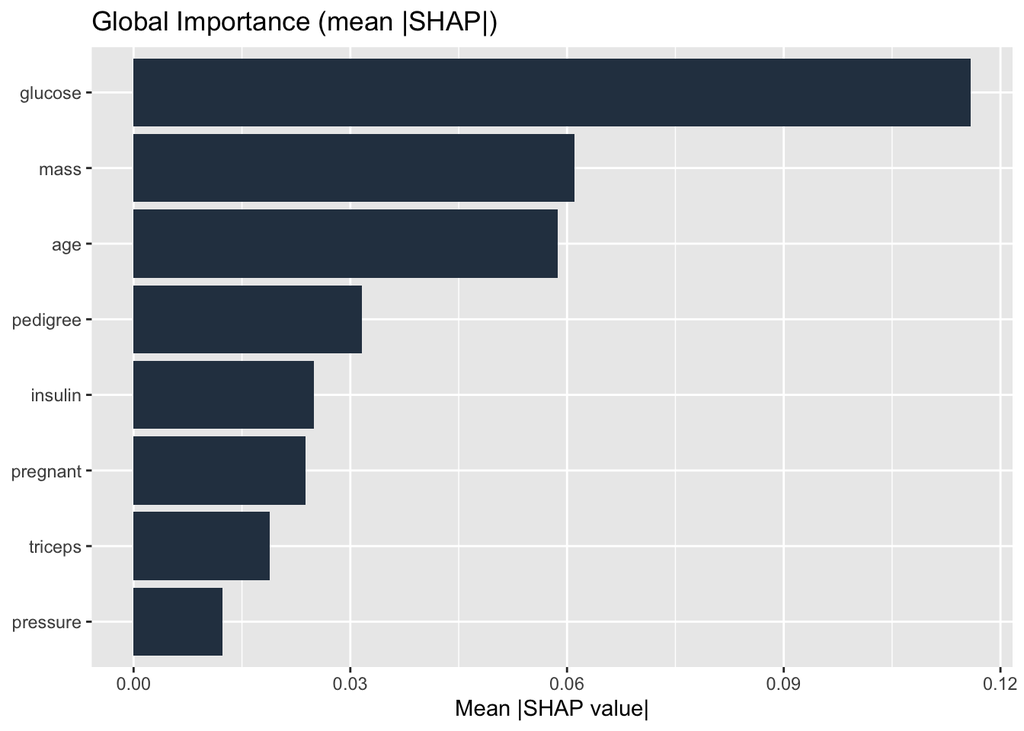

```r
# Compute global importance: mean(|SHAP|)
shap_importance <- data.frame(
  Variable = colnames(sh_values),
  Importance = apply(abs(sh_values), 2, mean)
)

# Sort and visualize
shap_importance <- shap_importance[order(-shap_importance$Importance), ]

ggplot(shap_importance,
       aes(x = reorder(Variable, Importance), y = Importance)) +
  geom_col(fill = "#2C3E50") +
  coord_flip() +
  labs(title = "Global Importance (mean |SHAP|)",
       x = NULL, y = "Mean |SHAP value|")
```

## 8.5 LIME (Local Surrogates)

LIME fits a simple surrogate model in the neighborhood of a single observation to explain a complex model’s prediction.

```r
# Create the explainer using the baked training predictors (as data.frame)
X_train <- as.data.frame(bake(prep_rec, new_data = train) %>% select(-diabetes))

explainer <- lime::lime(
  x = X_train,
  model = rf_fit,              # raw ranger model, not workflow
  bin_continuous = TRUE,
  n_bins = 4
)

explanations <- lime::explain(
  X_test[1:4, , drop = FALSE],
  explainer = explainer,
  n_features = 5,
  n_labels = 1
)

# Pick one test observation to explore
i <- 3

# Filter LIME results for that specific individual
lime_i <- explanations %>%
  filter(case == unique(case)[i]) %>%
  arrange(desc(feature_weight))

# Print numeric summary table
lime_i %>%
  select(feature, feature_value, feature_weight, feature_desc, model_r2,label, label_prob) %>%
  kbl2(digits = 3)
```

| feature | feature_value | feature_weight | feature_desc | model_r2 | label | label_prob |
| --- | --- | --- | --- | --- | --- | --- |
| glucose | 2.521 | 0.223 | 0.591 < glucose | 0.418 | pos | 0.687 |
| insulin | 4.726 | 0.078 | -0.175 < insulin | 0.418 | pos | 0.687 |
| age | 1.603 | 0.045 | 0.619 < age | 0.418 | pos | 0.687 |
| triceps | 1.861 | 0.030 | 0.35598 < triceps | 0.418 | pos | 0.687 |
| pedigree | -1.003 | -0.033 | pedigree <= -0.715 | 0.418 | pos | 0.687 |

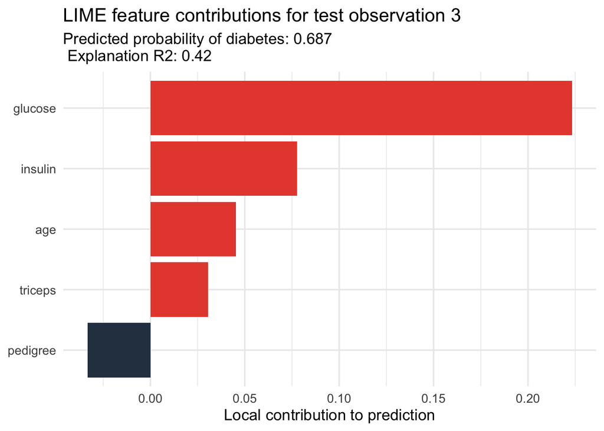

```r
# Plot bar chart of contributions
ggplot(lime_i, aes(x = reorder(feature, feature_weight),
                   y = feature_weight,
                   fill = feature_weight > 0)) +
  geom_col(show.legend = FALSE) +
  coord_flip() +
  labs(
    title = paste("LIME feature contributions for test observation", i),
    subtitle = paste0("Predicted probability of diabetes: ",
                      round(unique(lime_i$label_prob), 3),"\n Explanation R2: ", round(lime_i$model_r2[1],2)),
    x = NULL,
    y = "Local contribution to prediction"
  ) +
  scale_fill_manual(values = c("#2C3E50", "#E74C3C")) +
  theme_minimal(base_size = 13)
```

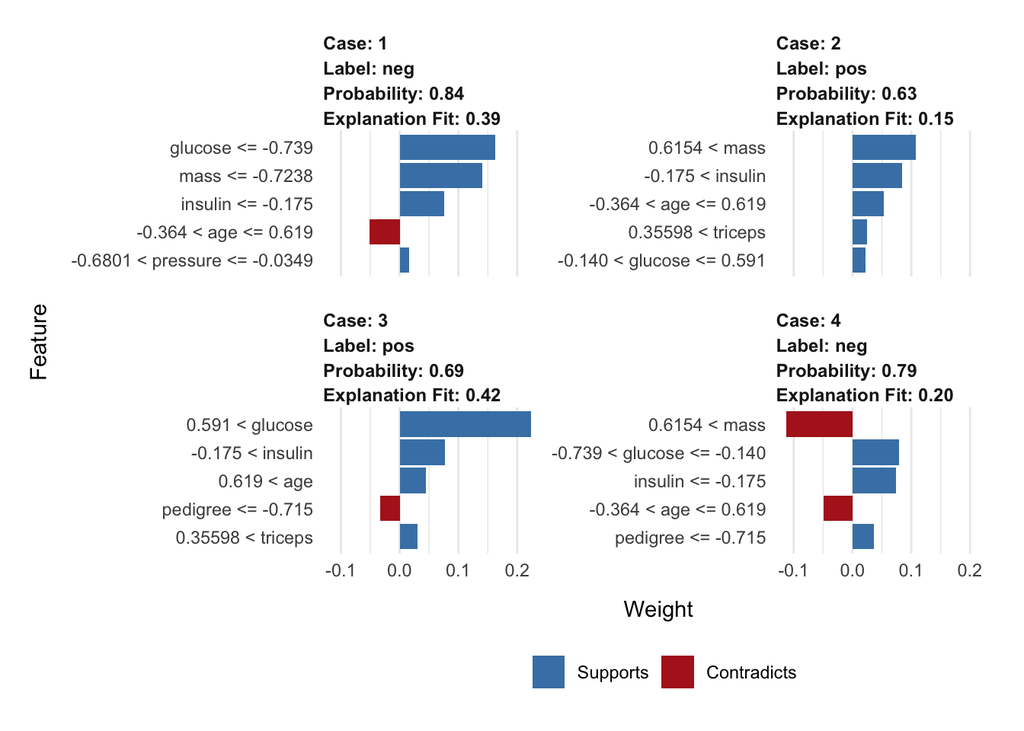

```r
plot_features(explanations)
```

```r
tibble(X_test[1:4,], pred = rf_predict(rf_fit, test_baked[1:4,])) %>% kbl2(digits = 3)
```

| pregnant | glucose | pressure | triceps | insulin | mass | pedigree | age | pred |
| --- | --- | --- | --- | --- | --- | --- | --- | --- |
| -0.829 | -1.205 | -0.519 | 0.009 | -0.175 | -0.840 | -0.378 | -0.200 | 0.157 |
| -1.124 | 0.525 | -2.616 | 0.703 | 0.329 | 1.549 | 5.888 | -0.036 | 0.634 |
| -0.534 | 2.521 | -0.196 | 1.861 | 4.726 | -0.275 | -1.003 | 1.603 | 0.687 |
| 0.055 | -0.373 | 1.578 | 0.009 | -0.175 | 0.753 | -0.896 | -0.282 | 0.206 |

# 9 Reporting Tips

- **For imbalanced outcomes,** report PR-AUC alongside the prevalence (its no-skill baseline), and say whether SMOTE, weighting, or a tuned threshold was used. Note that SMOTE and weighting change the predicted risks.
- Document how you chose features to visualize (e.g., top-5 by permutation importance).
- **Acknowledge assumptions/limitations:** PDP assumes weak dependence; ALE mitigates this but is still an approximation. LIME is *explanatory*, not causal — it shows which features the model relied on, not which features cause the outcome.
- **Quantify uncertainty where possible:** re-run interpretability summaries over resamples to assess stability.
- **Communicate clearly:** convert technical findings to public-health implications (modifiable risks, thresholds, nonlinearity).